# Road Types

**Key points of this script:**

- Find the type of road for each road in our dataset so as to add a new feature that we will use later in the regression;
- Road type classification;
- Find the city of each street (in our case it can be Ascoli, Roma, Grottaferrata, Frascati and Fregene) in order to facilitate the manual analysis we have done to identify the type of road;
- Looking at the acceleration graphically, we remove the outliers;

The same analysis will be repeated twice: once for a csv file containing all the roads obtained from measurements taken with the Iphone and the other for the file obtained from the Android phone.

Show which packages we use:

```python
import pandas as pd
import numpy as np
```

```python
# Load the iphonedata:
data = pd.read_csv('iphonedata.csv')
data.head()
```

|  | Elapse(ms) | Acc | Latitude | Longitude | Street | Elevation | Speed(Km/h) | Date | N_person | Car_type |
| --- | --- | --- | --- | --- | --- | --- | --- | --- | --- | --- |
| 0 | 3.0 | 9.901011 | 41.912503 | 12.451414 | Via Giovanni Bovio | 15.5 | 701.7 | 2019-06-12 16:01:17 | 3 | 0 |
| 1 | 3.0 | 10.008787 | 41.912503 | 12.451414 | Via Giovanni Bovio | 15.5 | 701.7 | 2019-06-12 16:01:17 | 3 | 0 |
| 2 | 3.0 | 11.233989 | 41.912503 | 12.451414 | Via Giovanni Bovio | 15.5 | 701.7 | 2019-06-12 16:01:17 | 3 | 0 |
| 3 | 3.0 | 10.025701 | 41.912503 | 12.451414 | Via Giovanni Bovio | 15.5 | 701.7 | 2019-06-12 16:01:17 | 3 | 0 |
| 4 | 3.0 | 9.254805 | 41.912503 | 12.451414 | Via Giovanni Bovio | 15.5 | 701.7 | 2019-06-12 16:01:17 | 3 | 0 |

What we see from the table above is that there are some speed values in km/h that are improbable! Therefore we have decided to remove all these "dirty" data that probably derive from telephone problems. In the next script, all speed values above 200 km/h.

A look at the different values that speed can take:

```python
a = list(data["Speed(Km/h)"].unique())
a = sorted(a)
print(a)
```

```
[1.1, 1.2, 1.3, 1.4, 1.5, 1.6, 1.7, 1.8, 1.9, 2.0, 2.1, 2.2, 2.3, 2.4, 2.5, 2.6, 2.7, 2.8, 2.9, 3.0, 3.1, 3.2, 3.3, 3.4, 3.5, 3.6, 3.7, 3.8, 3.9, 4.0, 4.1, 4.2, 4.3, 4.4, 4.5, 4.6, 4.7, 4.8, 4.9, 5.0, 5.1, 5.2, 5.3, 5.4, 5.5, 5.6, 5.7, 5.8, 5.9, 6.0, 6.1, 6.2, 6.3, 6.4, 6.5, 6.6, 6.7, 6.8, 6.9, 7.0,…
```

We see numerically how many measurements we have for the different roads:

```python
data.groupby(['Street']).count()
```

| Street | Elapse(ms) | Acc | Latitude | Longitude | Elevation | Speed(Km/h) | Date | N_person | Car_type |
| --- | --- | --- | --- | --- | --- | --- | --- | --- | --- |
| 21 | 165 | 165 | 165 | 165 | 165 | 165 | 165 | 165 | 165 |
| 22 | 60 | 60 | 60 | 60 | 60 | 60 | 60 | 60 | 60 |
| A90 | 105 | 105 | 105 | 105 | 105 | 105 | 105 | 105 | 105 |
| Borgo Sant'Angelo | 60 | 60 | 60 | 60 | 60 | 60 | 60 | 60 | 60 |
| Borgo Santo Spirito | 15 | 15 | 15 | 15 | 15 | 15 | 15 | 15 | 15 |
| Circonvallazione Casilina | 750 | 750 | 750 | 750 | 750 | 750 | 750 | 750 | 750 |
| Circonvallazione Tiburtina | 1568 | 1568 | 1568 | 1568 | 1568 | 1568 | 1568 | 1568 | 1568 |
| Grande Raccordo Anulare | 135 | 135 | 135 | 135 | 135 | 135 | 135 | 135 | 135 |
| Largo Alessi Galeazzo | 150 | 150 | 150 | 150 | 150 | 150 | 150 | 150 | 150 |
| Largo Porta Castello | 15 | 15 | 15 | 15 | 15 | 15 | 15 | 15 | 15 |
| Largo Trionfale | 105 | 105 | 105 | 105 | 105 | 105 | 105 | 105 | 105 |
| Largo Vittime del Terrorismo | 90 | 90 | 90 | 90 | 90 | 90 | 90 | 90 | 90 |
| Lungotevere Farnesina | 1035 | 1035 | 1035 | 1035 | 1035 | 1035 | 1035 | 1035 | 1035 |
| Lungotevere Gianicolense | 480 | 480 | 480 | 480 | 480 | 480 | 480 | 480 | 480 |
| Lungotevere R. Sanzio | 1500 | 1500 | 1500 | 1500 | 1500 | 1500 | 1500 | 1500 | 1500 |
| Lungotevere Sassia | 390 | 390 | 390 | 390 | 390 | 390 | 390 | 390 | 390 |
| Lungotevere degli Alberteschi | 135 | 135 | 135 | 135 | 135 | 135 | 135 | 135 | 135 |
| Lungotevere degli Anguillara | 570 | 570 | 570 | 570 | 570 | 570 | 570 | 570 | 570 |
| Lungotevere dei Pierleoni | 255 | 255 | 255 | 255 | 255 | 255 | 255 | 255 | 255 |
| Lungotevere in Sassia | 210 | 210 | 210 | 210 | 210 | 210 | 210 | 210 | 210 |
| Piazza A. Capponi | 60 | 60 | 60 | 60 | 60 | 60 | 60 | 60 | 60 |
| Piazza Adriana | 180 | 180 | 180 | 180 | 180 | 180 | 180 | 180 | 180 |
| Piazza Belli Giuseppe Gioachino | 60 | 60 | 60 | 60 | 60 | 60 | 60 | 60 | 60 |
| Piazza Camillo Finocchiaro Aprile | 75 | 75 | 75 | 75 | 75 | 75 | 75 | 75 | 75 |
| Piazza Castellani | 30 | 30 | 30 | 30 | 30 | 30 | 30 | 30 | 30 |
| Piazza Castroreale | 60 | 60 | 60 | 60 | 60 | 60 | 60 | 60 | 60 |
| Piazza Lodi | 60 | 60 | 60 | 60 | 60 | 60 | 60 | 60 | 60 |
| Piazza Pia | 315 | 315 | 315 | 315 | 315 | 315 | 315 | 315 | 315 |
| Piazza Ragusa | 300 | 300 | 300 | 300 | 300 | 300 | 300 | 300 | 300 |
| Piazza Trilussa | 60 | 60 | 60 | 60 | 60 | 60 | 60 | 60 | 60 |
| ... | ... | ... | ... | ... | ... | ... | ... | ... | ... |
| Via della Stazione di Ciampino | 60 | 60 | 60 | 60 | 60 | 60 | 60 | 60 | 60 |
| Via della Valle | 30 | 30 | 30 | 30 | 30 | 30 | 30 | 30 | 30 |
| Via delle Capannelle | 180 | 180 | 180 | 180 | 180 | 180 | 180 | 180 | 180 |
| Via delle Fosse di Castello | 135 | 135 | 135 | 135 | 135 | 135 | 135 | 135 | 135 |
| Via di Acqua Acetosa Anagnina | 90 | 90 | 90 | 90 | 90 | 90 | 90 | 90 | 90 |
| Via di Campo Romano | 120 | 120 | 120 | 120 | 120 | 120 | 120 | 120 | 120 |
| Via di Casal Morena | 1061 | 1061 | 1061 | 1061 | 1061 | 1061 | 1061 | 1061 | 1061 |
| Via di Porta Castello | 15 | 15 | 15 | 15 | 15 | 15 | 15 | 15 | 15 |
| Via di San Giovanni in Laterano | 2073 | 2073 | 2073 | 2073 | 2073 | 2073 | 2073 | 2073 | 2073 |
| Via di San Gregorio | 555 | 555 | 555 | 555 | 555 | 555 | 555 | 555 | 555 |
| Via di San Teodoro | 1215 | 1215 | 1215 | 1215 | 1215 | 1215 | 1215 | 1215 | 1215 |
| Via di Torre Malacena | 135 | 135 | 135 | 135 | 135 | 135 | 135 | 135 | 135 |
| Via di Torre Spaccata | 660 | 660 | 660 | 660 | 660 | 660 | 660 | 660 | 660 |
| Via di Valle Cupella | 105 | 105 | 105 | 105 | 105 | 105 | 105 | 105 | 105 |
| Via l'Aquila | 810 | 810 | 810 | 810 | 810 | 810 | 810 | 810 | 810 |
| Via la Spezia | 30 | 30 | 30 | 30 | 30 | 30 | 30 | 30 | 30 |
| Viale 1 Maggio | 540 | 540 | 540 | 540 | 540 | 540 | 540 | 540 | 540 |
| Viale A. A. Filarete | 90 | 90 | 90 | 90 | 90 | 90 | 90 | 90 | 90 |
| Viale Aventino | 330 | 330 | 330 | 330 | 330 | 330 | 330 | 330 | 330 |
| Viale Bastioni di Michelangelo | 300 | 300 | 300 | 300 | 300 | 300 | 300 | 300 | 300 |
| Viale Castrense | 120 | 120 | 120 | 120 | 120 | 120 | 120 | 120 | 120 |
| Viale Furio Camillo | 154 | 154 | 154 | 154 | 154 | 154 | 154 | 154 | 154 |
| Viale San Nilo | 1020 | 1020 | 1020 | 1020 | 1020 | 1020 | 1020 | 1020 | 1020 |
| Viale Scalo San Lorenzo | 469 | 469 | 469 | 469 | 469 | 469 | 469 | 469 | 469 |
| Viale del Parco del Celio | 330 | 330 | 330 | 330 | 330 | 330 | 330 | 330 | 330 |
| Viale dello Scalo San Lorenzo | 146 | 146 | 146 | 146 | 146 | 146 | 146 | 146 | 146 |
| Vico Jugario | 180 | 180 | 180 | 180 | 180 | 180 | 180 | 180 | 180 |
| Vicolo Anagnino | 540 | 540 | 540 | 540 | 540 | 540 | 540 | 540 | 540 |
| Vicolo Casilino | 45 | 45 | 45 | 45 | 45 | 45 | 45 | 45 | 45 |
| Vicolo del Quartiere | 30 | 30 | 30 | 30 | 30 | 30 | 30 | 30 | 30 |

231 rows × 9 columns

```python
s = list(data.Street.unique()) # A list of all the streets present in the dataframe
s.remove(np.nan)
# It may happen that the code was not able to find the name of the street from the latitude and longitude and
# consequently these are indicated with "nan" and therefore we eliminate them.
```

**Geopy** makes easy for Python developers to locate the coordinates of addresses, cities, countries, and landmarks across the globe using third-party geocoders and other data sources. Geopy includes geocoder classes for the OpenStreetMap Nominatim.

Geocoders each define at least a geocode method, for resolving a location from a string, and may define a reverse method, which resolves a pair of coordinates to an address.

```python
from geopy.geocoders import Nominatim

street= {} # We put here all the street for which we can retreive the type of road and the city
error = []  # We put here all the street for which we cannot retreive the type of road
geolocator = Nominatim()

for i in s:
    if (i not in street) and (i not in error):
        print(i)
        t = tuple(data.loc[data.Street == i][['Latitude', 'Longitude']].iloc[0])
        # Inside the data a street can be repeat more than one, therefore we take it only once

        location = geolocator.reverse(t) # Reverse method, which resolves a pair of coordinates to an address
        # Thanks the using try & except, we try to retreive the information regarding the different roads
        # but we saw that needed information are in different dictionaries, so using this method we solve the problem
        try:
            town = location.raw['address']['town']
        except:
            try:
                town = location.raw['address']['village']
            except:
                try:
                    town = location.raw['address']['suburb']
                except:
                    town = location.raw['address']['city']

        try:
            st = location.raw['address']['road']
        except:
            st = i

        location = geolocator.geocode(st + ' ' + town)
        try:
            street[i] = (location.raw['type'], town) # Save the type of road and the city where it is located
        except:
            print('AHIA',i) # In the case we do
            error.append(i) # Save in this list the streets for which we are not able to obtain the needed information
```

```
Via Giovanni Bovio
Via R. Caverni
Via Trionfale
Via Rodi
Via Bernardino Telesio
Via Giordano Bruno
Via Tommaso Campanella
Via Bumeliana
Via della Giuliana
Largo Trionfale
Via Leone IV
Via Germanico
Viale Bastioni di Michelangelo
Piazza del Risorgimento
Via del Mascherino
Via Stefano Porcari
Piazza A. Capponi
Via Giovanni Vitelleschi
Largo Porta Castello
Via di Porta Castello
Via delle Fosse di Castello
Piazza Adriana
Borgo Sant'Angelo
Piazza Pia
Via della Conciliazione
Lungotevere Sassia
Borgo Santo Spirito
Lungotevere in Sassia
Ponte Vittorio Emanuele II
Lungotevere Gianicolense
Lungotevere Farnesina
Salita del Buon Pastore
Vicolo del Quartiere
Piazza Trilussa
Lungotevere R. Sanzio
Piazza Belli Giuseppe Gioachino
Lungotevere degli Anguillara
Via della Gensola
Lungotevere degli Alberteschi
Piazza Castellani
```

[output cut: 177 more lines]

```
Via P. Zurla
Via Possidonio
Via A. Dulceri
Via Anassimandro
Via Alessi Galeazzo
Largo Alessi Galeazzo
Via Vibio Sequestre
Via Zenodossio
Viale A. A. Filarete
Via F. Laparelli
Via G. Serbelloni
Via dell'Acqua Bullicante
Vicolo Casilino
Via Labico
Via C. della Rocca
```

**Solve the error**

Thanks to the following code, for all the roads we previously had an error, we try to get the missing information. In the case in which we could not get the missing information then we decide to drop those streets.

You can notice that in this specific case just for one street we could not find the type of road.

```python
geolocator = Nominatim()

for i in set(error):

            print(i)
            t = tuple(data.loc[data.Street == i][['Latitude', 'Longitude']].iloc[0])

            try:
                location = geolocator.reverse(t)
            except:

                break

            try:
                town = location.raw['address']['town']
            except:
                try:
                    town = location.raw['address']['village']
                except:
                    try:
                        town = location.raw['address']['suburb']
                    except:
                        town = location.raw['address']['city']

            try:
                st = location.raw['address']['road']
            except:
                st = i

            print(location.raw)
            if '-' not in st:
                location = geolocator.geocode(st + ' ' + town)
            else:
                location = geolocator.geocode(st)
            try:
                street[i] = location.raw['type']
                print('hi')
                error.remove(i)
            except:

                pass
```

```
Via Silvia Rea
{'place_id': 14372709, 'licence': 'Data © OpenStreetMap contributors, ODbL 1.0. https://osm.org/copyright', 'osm_type': 'node', 'osm_id': 1270745487, 'lat': '41.8763327', 'lon': '12.5204745', 'display_name': "40, Piazza dell'Alberone, San Giovanni, Municipio Roma VII, Roma, RM, LAZ, 00181, Italia", …
```

```python
len(error) # "Via Silvia Rea"
```

```
1
```

In case we had more errors (as will occur later for the Android file), the following code allows to understand if the road for which we do not have the necessary information can be dropped or not.

The logic followed is the following:

1) For each street in the "errors" list we check how many of our measurements we have in the dataset:

```
- If this number is less than 1000 means that we have very little data to analyze on that road and therefore we drop it.
- This reasoning can no longer be followed if we have so many surveys because this would mean losing a large amount of data to analyze.
```

2) For the routes we cannot eliminate, we try to manually replace the type of road by searching the Internet.

```python
# We delete small "errors"

s = 0
l = []
for i in error:
    if len(data.loc[data.Street == i]) > 1000:
        l.append(i)
    print(i,len(data.loc[data.Street == i]))
    s += len(data.loc[data.Street == i])
```

```
Via Silvia Rea 60
```

```python
dropps = list(set(error) - set(l))
dropps # We check how many and which roads we remove
```

```
['Via Silvia Rea']
```

```python
# Now, is the time to actually remove the streets from our dataset
for i in dropps:
    data = data.drop(data.loc[data.Street == i].index)
```

Subsequently we create a new dataset with three columns that indicate respectively the name of the road, the type of road and the city.

Because of the different *try & except* previously used in the code to identify the city to which the streets belong, sometimes instead of having memorized the name of the city (i.e. "Roma") we have memorized the town hall (i.e., "Roma Municipio I"). If this occurs, we replace it with the name of the city (i.e. "Roma")

```python
# Create the dataset from the dictionary that we built before
types = pd.DataFrame.from_dict({'Street' : list(street.keys()),'type' : list(x[0] for x in street.values()),
                                'City':list(x[1] for x in street.values())})
```

```python
# Replace the not needed strings with blank space in order to obtain just the name of the city
types["City"] = types["City"].str.replace("Municipio ","")
types["City"] = types["City"].str.replace("I","")
types["City"] = types["City"].str.replace("V","")
types["City"] = types["City"].str.replace(" ","")
```

```python
types.City.unique() # Check how many different cities are present in the dataset
```

```
array(['Roma', 'Grottaferrata'], dtype=object)
```

We have decided not to have many different types of roads. In our dataset you will find the following types of roads ([OpenStreetMaps](https://wiki.openstreetmap.org/wiki/Main_Page)):

Therefore,in the case that a road was identified with another type we changed its type with one of the above list. Obviously, this change was not made casually but based on online documentation. This was made to not have too many different types: both to reduce the number of columns that will be created later with getdummies and also because the division into roads in OpenStreetMaps is very detailed and for our analysis we need more aggregated rather than specific data. In fact, for instance, we reported the roads that presented as "school" type in another type ("residential").

```python
types.type = types.type.replace(['trunk'], 'primary')

types.type = types.type.replace(['pedestrian', 'proposed'], 'tertiary')
types.type = types.type.replace(['park', 'platform', 'townhall','school', 'station', 'track', 'unclassified', 'service',
                                'administrative','living_street'], 'residential')#.groupby(['type']).count()
```

```python
types.groupby(['type']).count() # Show how many different types of streets we have
```

| type | Street | City |
| --- | --- | --- |
| primary | 36 | 36 |
| residential | 96 | 96 |
| secondary | 87 | 87 |
| tertiary | 11 | 11 |

```python
# Merge together the two dataframe: the types of street and our initial dataset
complete = data.merge(types, left_on= 'Street', right_on= 'Street')
```

```python
complete # Show the result
```

|  | Elapse(ms) | Acc | Latitude | Longitude | Street | Elevation | Speed(Km/h) | Date | N_person | Car_type | type | City |
| --- | --- | --- | --- | --- | --- | --- | --- | --- | --- | --- | --- | --- |
| 0 | 3.0 | 9.901011 | 41.912503 | 12.451414 | Via Giovanni Bovio | 15.5 | 701.7 | 2019-06-12 16:01:17 | 3 | 0 | residential | Roma |
| 1 | 3.0 | 10.008787 | 41.912503 | 12.451414 | Via Giovanni Bovio | 15.5 | 701.7 | 2019-06-12 16:01:17 | 3 | 0 | residential | Roma |
| 2 | 3.0 | 11.233989 | 41.912503 | 12.451414 | Via Giovanni Bovio | 15.5 | 701.7 | 2019-06-12 16:01:17 | 3 | 0 | residential | Roma |
| 3 | 3.0 | 10.025701 | 41.912503 | 12.451414 | Via Giovanni Bovio | 15.5 | 701.7 | 2019-06-12 16:01:17 | 3 | 0 | residential | Roma |
| 4 | 3.0 | 9.254805 | 41.912503 | 12.451414 | Via Giovanni Bovio | 15.5 | 701.7 | 2019-06-12 16:01:17 | 3 | 0 | residential | Roma |
| 5 | 3.0 | 8.082442 | 41.912503 | 12.451414 | Via Giovanni Bovio | 15.5 | 701.7 | 2019-06-12 16:01:17 | 3 | 0 | residential | Roma |
| 6 | 3.0 | 10.532997 | 41.912503 | 12.451414 | Via Giovanni Bovio | 15.5 | 701.7 | 2019-06-12 16:01:17 | 3 | 0 | residential | Roma |
| 7 | 3.0 | 9.343570 | 41.912503 | 12.451414 | Via Giovanni Bovio | 15.5 | 701.7 | 2019-06-12 16:01:17 | 3 | 0 | residential | Roma |
| 8 | 3.0 | 10.403516 | 41.912503 | 12.451414 | Via Giovanni Bovio | 15.5 | 701.7 | 2019-06-12 16:01:17 | 3 | 0 | residential | Roma |
| 9 | 3.0 | 10.425520 | 41.912503 | 12.451414 | Via Giovanni Bovio | 15.5 | 701.7 | 2019-06-12 16:01:17 | 3 | 0 | residential | Roma |
| 10 | 3.0 | 10.723251 | 41.912503 | 12.451414 | Via Giovanni Bovio | 15.5 | 701.7 | 2019-06-12 16:01:17 | 3 | 0 | residential | Roma |
| 11 | 3.0 | 10.560539 | 41.912503 | 12.451414 | Via Giovanni Bovio | 15.5 | 701.7 | 2019-06-12 16:01:17 | 3 | 0 | residential | Roma |
| 12 | 3.0 | 10.195448 | 41.912503 | 12.451414 | Via Giovanni Bovio | 15.5 | 701.7 | 2019-06-12 16:01:17 | 3 | 0 | residential | Roma |
| 13 | 3.0 | 9.345366 | 41.912503 | 12.451414 | Via Giovanni Bovio | 15.5 | 701.7 | 2019-06-12 16:01:17 | 3 | 0 | residential | Roma |
| 14 | 3.0 | 9.837543 | 41.912503 | 12.451414 | Via Giovanni Bovio | 15.5 | 701.7 | 2019-06-12 16:01:17 | 3 | 0 | residential | Roma |
| 15 | 4.0 | 8.613688 | 41.912494 | 12.451478 | Via Giovanni Bovio | 17.2 | 19.5 | 2019-06-12 16:01:18 | 3 | 0 | residential | Roma |
| 16 | 4.0 | 9.558074 | 41.912494 | 12.451478 | Via Giovanni Bovio | 17.2 | 19.5 | 2019-06-12 16:01:18 | 3 | 0 | residential | Roma |
| 17 | 4.0 | 10.761571 | 41.912494 | 12.451478 | Via Giovanni Bovio | 17.2 | 19.5 | 2019-06-12 16:01:18 | 3 | 0 | residential | Roma |
| 18 | 4.0 | 10.387649 | 41.912494 | 12.451478 | Via Giovanni Bovio | 17.2 | 19.5 | 2019-06-12 16:01:18 | 3 | 0 | residential | Roma |
| 19 | 4.0 | 10.771750 | 41.912494 | 12.451478 | Via Giovanni Bovio | 17.2 | 19.5 | 2019-06-12 16:01:18 | 3 | 0 | residential | Roma |
| 20 | 4.0 | 9.599538 | 41.912494 | 12.451478 | Via Giovanni Bovio | 17.2 | 19.5 | 2019-06-12 16:01:18 | 3 | 0 | residential | Roma |
| 21 | 4.0 | 9.331445 | 41.912494 | 12.451478 | Via Giovanni Bovio | 17.2 | 19.5 | 2019-06-12 16:01:18 | 3 | 0 | residential | Roma |
| 22 | 4.0 | 11.395353 | 41.912494 | 12.451478 | Via Giovanni Bovio | 17.2 | 19.5 | 2019-06-12 16:01:18 | 3 | 0 | residential | Roma |
| 23 | 4.0 | 10.381811 | 41.912494 | 12.451478 | Via Giovanni Bovio | 17.2 | 19.5 | 2019-06-12 16:01:18 | 3 | 0 | residential | Roma |
| 24 | 4.0 | 10.465637 | 41.912494 | 12.451478 | Via Giovanni Bovio | 17.2 | 19.5 | 2019-06-12 16:01:18 | 3 | 0 | residential | Roma |
| 25 | 4.0 | 9.445957 | 41.912494 | 12.451478 | Via Giovanni Bovio | 17.2 | 19.5 | 2019-06-12 16:01:18 | 3 | 0 | residential | Roma |
| 26 | 4.0 | 10.424472 | 41.912494 | 12.451478 | Via Giovanni Bovio | 17.2 | 19.5 | 2019-06-12 16:01:18 | 3 | 0 | residential | Roma |
| 27 | 4.0 | 10.047257 | 41.912494 | 12.451478 | Via Giovanni Bovio | 17.2 | 19.5 | 2019-06-12 16:01:18 | 3 | 0 | residential | Roma |
| 28 | 4.0 | 9.123078 | 41.912494 | 12.451478 | Via Giovanni Bovio | 17.2 | 19.5 | 2019-06-12 16:01:18 | 3 | 0 | residential | Roma |
| 29 | 4.0 | 10.077194 | 41.912494 | 12.451478 | Via Giovanni Bovio | 17.2 | 19.5 | 2019-06-12 16:01:18 | 3 | 0 | residential | Roma |
| ... | ... | ... | ... | ... | ... | ... | ... | ... | ... | ... | ... | ... |
| 69299 | 1005.0 | 10.023007 | 41.879401 | 12.543810 | Via C. della Rocca | 37.7 | 38.4 | 2019-04-29 10:15:23 | 1 | 0 | secondary | Roma |
| 69300 | 1005.0 | 10.148746 | 41.879401 | 12.543810 | Via C. della Rocca | 37.7 | 38.4 | 2019-04-29 10:15:23 | 1 | 0 | secondary | Roma |
| 69301 | 1005.0 | 10.198293 | 41.879401 | 12.543810 | Via C. della Rocca | 37.7 | 38.4 | 2019-04-29 10:15:23 | 1 | 0 | secondary | Roma |
| 69302 | 1005.0 | 9.136700 | 41.879401 | 12.543810 | Via C. della Rocca | 37.7 | 38.4 | 2019-04-29 10:15:23 | 1 | 0 | secondary | Roma |
| 69303 | 1005.0 | 10.623858 | 41.879401 | 12.543810 | Via C. della Rocca | 37.7 | 38.4 | 2019-04-29 10:15:23 | 1 | 0 | secondary | Roma |
| 69304 | 1005.0 | 9.823023 | 41.879401 | 12.543810 | Via C. della Rocca | 37.7 | 38.4 | 2019-04-29 10:15:23 | 1 | 0 | secondary | Roma |
| 69305 | 1005.0 | 9.369316 | 41.879401 | 12.543810 | Via C. della Rocca | 37.7 | 38.4 | 2019-04-29 10:15:23 | 1 | 0 | secondary | Roma |
| 69306 | 1005.0 | 9.554781 | 41.879401 | 12.543810 | Via C. della Rocca | 37.7 | 38.4 | 2019-04-29 10:15:23 | 1 | 0 | secondary | Roma |
| 69307 | 1005.0 | 9.889784 | 41.879401 | 12.543810 | Via C. della Rocca | 37.7 | 38.4 | 2019-04-29 10:15:23 | 1 | 0 | secondary | Roma |
| 69308 | 1005.0 | 11.041190 | 41.879401 | 12.543810 | Via C. della Rocca | 37.7 | 38.4 | 2019-04-29 10:15:23 | 1 | 0 | secondary | Roma |
| 69309 | 1005.0 | 9.522149 | 41.879401 | 12.543810 | Via C. della Rocca | 37.7 | 38.4 | 2019-04-29 10:15:23 | 1 | 0 | secondary | Roma |
| 69310 | 1005.0 | 9.009914 | 41.879401 | 12.543810 | Via C. della Rocca | 37.7 | 38.4 | 2019-04-29 10:15:23 | 1 | 0 | secondary | Roma |
| 69311 | 1005.0 | 9.236243 | 41.879401 | 12.543810 | Via C. della Rocca | 37.7 | 38.4 | 2019-04-29 10:15:23 | 1 | 0 | secondary | Roma |
| 69312 | 1005.0 | 10.837314 | 41.879401 | 12.543810 | Via C. della Rocca | 37.7 | 38.4 | 2019-04-29 10:15:23 | 1 | 0 | secondary | Roma |
| 69313 | 1005.0 | 10.354268 | 41.879401 | 12.543810 | Via C. della Rocca | 37.7 | 38.4 | 2019-04-29 10:15:23 | 1 | 0 | secondary | Roma |
| 69314 | 1006.0 | 9.928104 | 41.879349 | 12.543920 | Via C. della Rocca | 37.8 | 39.0 | 2019-04-29 10:15:24 | 1 | 0 | secondary | Roma |
| 69315 | 1006.0 | 10.458302 | 41.879349 | 12.543920 | Via C. della Rocca | 37.8 | 39.0 | 2019-04-29 10:15:24 | 1 | 0 | secondary | Roma |
| 69316 | 1006.0 | 9.750274 | 41.879349 | 12.543920 | Via C. della Rocca | 37.8 | 39.0 | 2019-04-29 10:15:24 | 1 | 0 | secondary | Roma |
| 69317 | 1006.0 | 9.605974 | 41.879349 | 12.543920 | Via C. della Rocca | 37.8 | 39.0 | 2019-04-29 10:15:24 | 1 | 0 | secondary | Roma |
| 69318 | 1006.0 | 10.649305 | 41.879349 | 12.543920 | Via C. della Rocca | 37.8 | 39.0 | 2019-04-29 10:15:24 | 1 | 0 | secondary | Roma |
| 69319 | 1006.0 | 10.329570 | 41.879349 | 12.543920 | Via C. della Rocca | 37.8 | 39.0 | 2019-04-29 10:15:24 | 1 | 0 | secondary | Roma |
| 69320 | 1006.0 | 9.707463 | 41.879349 | 12.543920 | Via C. della Rocca | 37.8 | 39.0 | 2019-04-29 10:15:24 | 1 | 0 | secondary | Roma |
| 69321 | 1006.0 | 10.049053 | 41.879349 | 12.543920 | Via C. della Rocca | 37.8 | 39.0 | 2019-04-29 10:15:24 | 1 | 0 | secondary | Roma |
| 69322 | 1006.0 | 9.400152 | 41.879349 | 12.543920 | Via C. della Rocca | 37.8 | 39.0 | 2019-04-29 10:15:24 | 1 | 0 | secondary | Roma |
| 69323 | 1006.0 | 9.436976 | 41.879349 | 12.543920 | Via C. della Rocca | 37.8 | 39.0 | 2019-04-29 10:15:24 | 1 | 0 | secondary | Roma |
| 69324 | 1006.0 | 10.411898 | 41.879349 | 12.543920 | Via C. della Rocca | 37.8 | 39.0 | 2019-04-29 10:15:24 | 1 | 0 | secondary | Roma |
| 69325 | 1006.0 | 10.178534 | 41.879349 | 12.543920 | Via C. della Rocca | 37.8 | 39.0 | 2019-04-29 10:15:24 | 1 | 0 | secondary | Roma |
| 69326 | 1006.0 | 9.473649 | 41.879349 | 12.543920 | Via C. della Rocca | 37.8 | 39.0 | 2019-04-29 10:15:24 | 1 | 0 | secondary | Roma |
| 69327 | 1006.0 | 8.546028 | 41.879349 | 12.543920 | Via C. della Rocca | 37.8 | 39.0 | 2019-04-29 10:15:24 | 1 | 0 | secondary | Roma |
| 69328 | 1006.0 | 9.944121 | 41.879349 | 12.543920 | Via C. della Rocca | 37.8 | 39.0 | 2019-04-29 10:15:24 | 1 | 0 | secondary | Roma |

69329 rows × 12 columns

# ROAD SURFACE FEATURE

A very important but at the same time very difficult step was to identify the road surface. In fact, this passage was done by hand: each road was inserted on Google Maps and we checked from the photo if it was of sampietrini or asphalt.

The classification:

**0** street without sampietrini (asphalt road);

**1** street with sampietrini;

We do not exclude the presence of human errors.

```python
# The first step is to check the city of each road in order to put the correct address in Google Maps
l = ['Via di Porta Castello', 'Via Rossano Calabro', 'Via di San Gregorio', 'Via Giovanni Bovio', 'Via Fattoria Rampa',
     'Via Gasperina', 'Via Monasterace', 'Via Eurialo', 'Grande Raccordo Anulare', 'Via Zenodossio', 'Via Sorgenti',
     'Via del Fosso Centroni', 'Via Casalmonferrato', 'Via Ulivi', 'Ponte Vittorio Emanuele II', 'Via Torre di Mezzavia',
     'Via Fregene', 'Via Colle delle Ginestre', 'Viale San Nilo', 'Via Capistrano', 'Via Lanusei',
     'Piazza Camillo Finocchiaro Aprile', 'Via P. Zurla', 'Via Valle Marciana', 'Via Cerreto di Spoleto',
     'Via L. Petroselli', 'Via Fonti del Clitunno', 'Via di Valle Cupella', 'Via Guglielmo Quattrucci', 'Via di Campo Romano',
     'Piazzale Appio', 'Via di Torre Malacena', 'Via C. della Rocca', 'Via A. Dulceri', 'Piazza Castellani', 'Via Albenga',
     'Lungotevere Gianicolense', 'Via V. Lamaro', 'Via Possidonio', 'Via Germanico', 'Via della Conciliazione', 'Via Cropani',
     'Via Giovanni Vitelleschi', 'Via delle Capannelle', "Via alme'", 'Ponte Palatino', 'Via Antonio Santovetti', 'Via Albidona',
     'Via Alberto da Giussano', 'Via di Acqua Acetosa Anagnina', 'Viale Bastioni di Michelangelo', 'Piazza del Colosseo',
     'Via Bartolomeo Gosio', 'Piazza Pia', 'Vicolo Anagnino', 'Via della Giuliana', 'Via Giordano Bruno', 'Via Terni',
     'Via Nocera Umbra', 'Via Pontoglio', 'Via della Cavona', 'Piazza di Poggio Tulliano', 'Via Rodi', 'Lungotevere in Sassia',
     'Largo Trionfale', 'Via Labico', 'Lungotevere degli Alberteschi', 'Via del Mascherino', 'Via Aulo Plauzio', 'Via C. Bellico',
     'Via di San Giovanni in Laterano', 'Via del Fosso di S. Andrea', 'Via Seminara', 'Via Fivizzano', 'Via della Rovere',
     'Via del Boschetto']

for i in l:
    print(i,complete.loc[complete.Street == i]["City"].head(1))
```

```
Via di Porta Castello 4424    Roma
Name: City, dtype: object
Via Rossano Calabro 47541    Grottaferrata
Name: City, dtype: object
Via di San Gregorio 14069    Roma
Name: City, dtype: object
Via Giovanni Bovio 0    Roma
Name: City, dtype: object
Via Fattoria Rampa 27004    Roma
Name: City, dtype: object
Via Gasperina 28039    Roma
Name: City, dtype: object
Via Monasterace 49487    Roma
Name: City, dtype: object
Via Eurialo 58139    Roma
Name: City, dtype: object
Grande Raccordo Anulare 26809    Roma
Name: City, dtype: object
Via Zenodossio 68324    Roma
Name: City, dtype: object
Via Sorgenti 37080    Grottaferrata
Name: City, dtype: object
Via del Fosso Centroni 31080    Roma
Name: City, dtype: object
Via Casalmonferrato 22125    Roma
Name: City, dtype: object
Via Ulivi 34245    Grottaferrata
Name: City, dtype: object
Ponte Vittorio Emanuele II 5759    Roma
Name: City, dtype: object
Via Torre di Mezzavia 27739    Roma
Name: City, dtype: object
Via Fregene 20475    Roma
Name: City, dtype: object
Via Colle delle Ginestre 51317    Grottaferrata
Name: City, dtype: object
Viale San Nilo 32865    Grottaferrata
Name: City, dtype: object
Via Capistrano 26749    Roma
Name: City, dtype: object
```

[output cut: 97 more lines]

```
Name: City, dtype: object
Via C. Bellico 50387    Roma
Name: City, dtype: object
Via di San Giovanni in Laterano 15959    Roma
Name: City, dtype: object
Via del Fosso di S. Andrea 30405    Roma
Name: City, dtype: object
Via Seminara 49787    Roma
Name: City, dtype: object
Via Fivizzano 62264    Roma
Name: City, dtype: object
Via della Rovere 33885    Grottaferrata
Name: City, dtype: object
Via del Boschetto 35505    Grottaferrata
Name: City, dtype: object
```

Let's take a closer look at how the graphs are on the measurements taken on "san pietrini" streets.

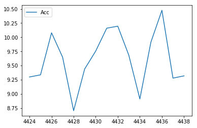

```python
complete.loc[complete.Street == "Via di Porta Castello"].plot(y = "Acc")
```

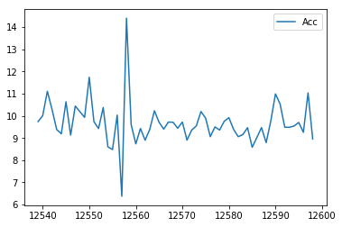

```python
complete.loc[complete.Street == "Via dei Cerchi"].plot(y = "Acc")
```

Our classification regarding the feature **"Road_Surface""** is as follows:

- **0** for asphalt road;
- **1** for "san pietrini" road;

```python
# We created this new feature by assigning 0 to all roads and then for those where we had san pietrini we replaced it with 1
complete['Road_Surface'] = 0
san_pietr = ['Piazza della Consolazione', 'Borgo Sant\'Angelo','Viale Aventino','Via del Foro Olitorio',
    'Piazza Trilussa','Piazza di Sant\'Anastasia',
     'Via del Teatro di Marcello','Via dei Cerchi','Vico Jugario','Vicolo del Quartiere','Via della Consolazione',
     'Piazza di Monte Savello','Borgo Santo Spirito','Via di San Teodoro', 'Piazza Adriana','Via dei Foraggi',
    'Via della Conciliazione','Via del Mascherino',"Via di Porta Castello"]
for i in san_pietr:
    complete.loc[complete.Street == i, ['Road_Surface']] = 1
```

# "OUTLIERS"

When the phone is placed horizontally or vertically and is not subject to solicitations (jolts) the accelerometer sensor is affected by gravity which measures ($9.8 m/s^2$). Therefore, we are going to manually see all those measurements (and therefore trips) for which the acceleration does not respect what was said. In these cases it could happen that the phone has been moved, used or the phone's accelerometer has not worked well.

```python
# For each street in our dataframe we save a list with all the accelerations and
# therefore we consider in the same list also several trips made on the same road
m ={}
for i in complete.Street.unique():
    m[i] = complete[complete.Street == i].Acc.mean()
```

```python
# Save in "s" all the street for which there are accelerations greater than 10 or less than 9
s = []
for i in m.keys():
    if (m[i] < 9) or m[i] > 10 :
        s.append(i)
```

```python
len(s) # How many are these streets?
```

```
43
```

Now let's look graphically at each of these 43 roads that have different values from those we expected for acceleration. Different situations that can be noticed from the following graphs:

1) There are some jolts: we cannot remove them from the analysis because they are just what we need! They help us to understand if the road is in good condition or not and therefore if the car has taken holes or not.

2) "Bad" measurements: as already mentioned before, in these cases the phone could have been moved or the accelerometer did not work properly.

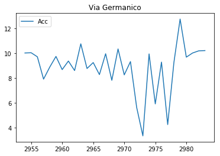

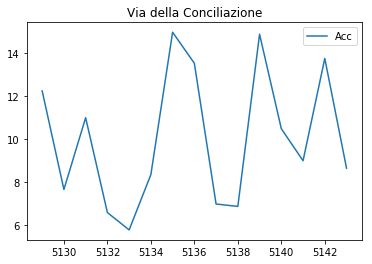

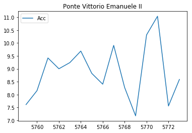

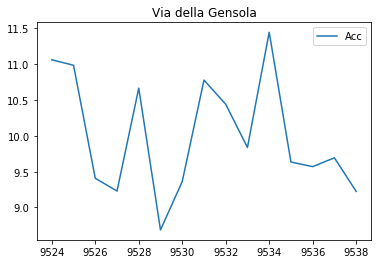

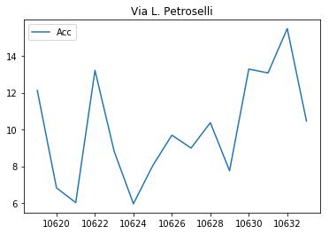

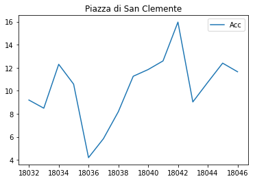

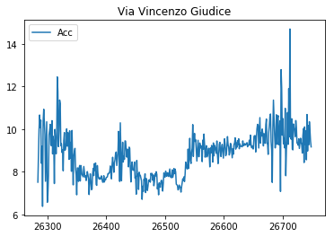

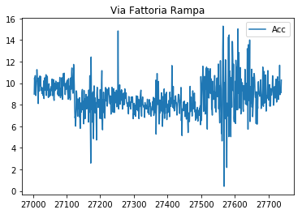

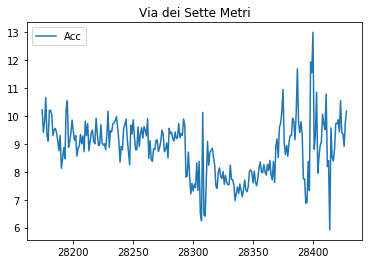

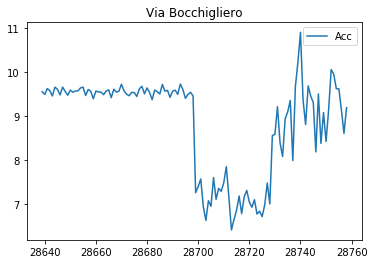

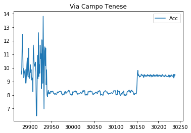

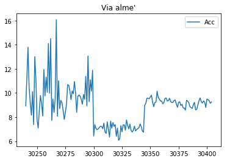

[31 more figures not shown]

```python
for i in s:
    complete[complete.Street == i].plot(y = 'Acc', title = i)
```

From the graphs is what we noticed and removed from our dataframe:

- "**Via delle Piave", "Via Fico", "Via Pontoglio"**, they have too few measurements (about 15 each). Therefore we have decided to eliminate them because we do not know if the phone has malfunctioned or if the car has passed only a few moments on such a street. Since we cannot know it and we would lose only very little data, we preferred to remove it.
- **"Via Seminara"** has a strange trend, we eliminate it.
- **"Via G. Delitala"** from the graph it can be seen how the phone was not positioned well at the beginning of the measurement and therefore we removed only that "wrong" part of the measurements.
- **"Via della Conciliazione"**, even if with few measurements we have decided to keep it because it is a street with "sapietrini" and we do not have many in our dataset.

```python
for i in s:
    t =complete[complete.Street == i]["Road_Surface"].iloc[0]
    if t == 1:
        print(i,t)
```

```
Via della Conciliazione 1
```

```python
complete = complete.drop(complete.loc[complete.Street == 'Via Piave'].index)
complete = complete.drop(complete.loc[complete.Street == 'Via Seminara'].index)
complete = complete.drop(complete.loc[complete.Street == 'Via Fico'].index)
complete = complete.drop(complete.loc[complete.Street == 'Via Pontoglio'].index)
complete = complete.drop(complete.loc[(complete.Street == 'Via G. Delitala') & (complete.Acc < 9)].index)
```

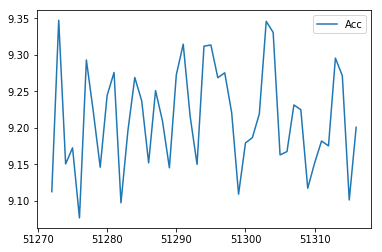

```python
complete.loc[(complete.Street == 'Via G. Delitala')].plot(y="Acc")
```

# SAVE DATASET

Below is the number of roads we have collected:

```python
len(complete.Street.unique())
```

```
226
```

```python
complete.to_csv('complete.csv', index=False) # Save into csv
```

### Now repeat the same analysis for the data obtained from Android phone

```python
data = pd.read_csv('androiddata.csv')
```

```python
data.groupby(['Street']).count()
```

[output not shown]

357 rows × 11 columns

```python
s = list(data.Street.unique())
s.remove(np.nan)
```

[output not shown]